# Wrangling Bird Data

Mar Heron

March 30, 2026

```r
# Load R Packages
library(tidyverse)
library(dplyr)
library(visdat)
library(ggplot2)
```

# Introduction

## Data Wrangling

Data wrangling is about making data more usable. By *usable*, I mean easier to view, make graphics out of, and perform statistical tests with. There are many different ways to wrangle data so that it becomes more usable. Data wrangling tasks include things like selecting a subset of rows or columns to look at, creating new variables, re-ordering the rows of a dataset, combining datasets, and more. Another part of data wrangling is dealing with missing values (also called missingness). This is a common problem, and luckily there are a lot of different methods to go about fixing data with missing values.

The data wrangling methods I’ll be focusing on in this project are:

- filter()
- select()
- arrange()
- slice()
- mean imputation

## Dataset

For this project, I chose the *birds* dataset within tidytuesday’s Bird Sightings at Sea entry on GitHub. This dataset caught my eye because I love birdwatching and learning about birds. However, I don’t know much about seabirds, so I thought this would be the perfect opportunity to change that!

The *birds* dataset has information about bird sightings at sea around New Zealand from the view of a ship during the years 1969 to 1990. There are 26 variables in the dataset, including the species name, age, plumage, number of birds seen, and various behaviors observed.

This dataset is great to use for practicing methods for fixing missing data because it has a quite a few missing values and plenty of different variables to focus on.

[Link to dataset csv](https://raw.githubusercontent.com/rfordatascience/tidytuesday/main/data/2026/2026-04-14/birds.csv)

[Link to dataset information](https://github.com/rfordatascience/tidytuesday/blob/main/data/2026/2026-04-14/readme.md#birdscsv)

# Exploring the Data

## Determining Missingness

### Step 1: Number of rows and columns

To see just how much of the *birds* data is missing, I’m going to first check the dimensions (number of rows and columns) of the dataset using the *dim()* function.

```r
dim(birds)
```

```
## [1] 49019    26
```

### Step 2: Number of observations

Because the output shows that there are 49,019 rows and 26 columns, I’m then going to multiply these two values to find the total number of observations/cells.

```r
49019*26
```

```
## [1] 1274494
```

### Step 3: Number of missing values

Next, I’m going to use the *sum()* and *is.na()* functions to determine the total number of missing values in the dataset.

```r
sum(is.na(birds))
```

```
## [1] 579190
```

### Step 4: Proportion of data that is missing

Finally, I’m going to see what proportion of the total observations are missing by dividing the number of missing values (579,190) by the number of total observations (1,274,494). With this information, I now know that about 45% of the observations are missing from the dataset.

```r
579190/1274494
```

```
## [1] 0.454447
```

# Choosing a Subset of the Data

### The filter() function

Because this dataset is very large, I want to narrow it down to a more manageable size. To do this, I’ll first choose to focus on one type of bird in particular. For this project, I’ll only look at grey-faced petrels. I will create a new datasat called *gfp* using the filter() function. This function allows me to only keep the rows with “Grey-faced petrel” as the value for the *species_common_name* variable.

```r
gfp <- filter(birds, species_common_name == "Grey-faced petrel")
```

### The select() function

I’ll also only choose a few variables/columns to keep. I will do this using the *select()* function. This function allows me to select certain columns to keep. I will call this new dataset *gfp_select*. For this project, I will look at the following variables:

- **count:** Total number of birds counted in the observation
- **n_feeding:** Number of birds observed to be feeding
- **n_sitting_on_water:** Number of birds observed to be sitting on the water
- **n_flying_past:** Number of birds observed to be flying past the ship

```r
gfp_select <- select(gfp, count, n_feeding, n_sitting_on_water, n_flying_past)
```

### The arrange() function

Now that the dataset has been narrowed down a little bit more, we can arrange the rows in order from the highest count to the lowest count. This will help us visualize the makeup of observations with higher bird counts. To do this, I will use the *arrange()* function. Because the default order of the *arrange()* function is ascending order, I’ll need to include *desc()* before the *count* variable to ensure it is put in descending order instead. I’ll name this newly ordered version of the dataset *gfp_desc*.

```r
gfp_desc <- arrange(gfp_select, desc(count))
```

### The slice() function

I’d like to only use the rows with bird counts on the higher end when I fix the missing values, so I’ll create a new dataset with only the first 1/4 of the rows. The dataset currently has 2,597 rows, so 1/4 of that would be about 649. To get the first 649 rows, I will use the *slice_head()* function, which produces the first *n* rows of a dataset, with *n* being the number of rows you want to select. I will name this new dataset *gfp_slice*.

```r
gfp_slice <- slice_head(gfp_desc, n = 649)
```

### Checking missingness

At this point, we’ve got a much smaller subset of the original data. I’d like to visualize the amount of missing values by using the *vis_miss()* function within the *vidat* package. The *vis_miss()* function creates a graphic showing the percentages of each column and the whole dataset that are missing.

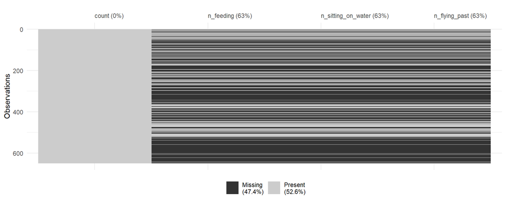

```r
vis_miss(gfp_slice)+
  theme(axis.text.x = element_text(angle = 0))
```

**Interpretation:** As you can see in the graphic above, almost half of the data are missing (47.4%). Notably, the *count* column has no missing values, while the rest of the columns all have missing values. This makes sense, as recording the total number of birds spotted (the *count* variable) seems to have been the main goal of the original *birds* data collection project. Additionally, not only do all of the columns aside from *count* have the same amount of missing data (63%), but all of the rows with missing values have missing values in all three of the other columns. This is interesting, but it also makes sense. Perhaps the person in charge of each of the bird observations with missing values forgot to take note of the amount of birds engaging in different behaviors (feeding, sitting in the water, or flying past the ship). It’s also possible that all of the rows with missing data were collected at a time when those behaviors hadn’t started being tracked yet. Either way, now that we know there is an even larger percentage of the Grey Faced Petrel dataset missing compared to the original birds dataset, we can work on dealing with that missingness.

[Website used to help adjust the axis labels in the above graphic](https://stackoverflow.com/questions/52146856/vis-miss-make-column-titles-vertical) [Website used to help adjust the sizing of the above graphic](https://www.andrewheiss.com/blog/2022/06/23/long-labels-ggplot/)

# Dealing with Missing Data

### Listwise & pairwise deletion

There are many possible ways of dealing with missing data. You could remove all rows with missing values from a dataset, which is called listwise deletion. You could also only remove rows with missing values in the columns that you’re focusing your analysis on. While listwise and pairwise deletion may be simple, they involve disregarding potentially important data from your analysis. This can lead to biased and inaccurate results.

### Mean & regression imputation

Other options include mean or regression imputation. Mean imputation replaces missing values with the mean value for that column. The problem with this method is that it artificially decreases the amount of variability within your dataset. In other words, replacing the missing values with the mean makes it seem like the data points vary much less from each other than they actually do. Regression imputation works by replacing missing values with a predicted value based on the value for another variable in the dataset. This other variable that helps predict the missing value should be highly correlated with the variable of the missing value in order for the prediction to be most accurate. The variability is not artificially lowered with regression imputation like it is with mean imputation, making it generally a better choice.

### Determining which method to use for our dataset

In the *gfp_slice* dataset, all values in the *count* column are present, and the rest of the columns have some rows with missing values (labeled as *“NA”*). If we want to use regression imputation to fill in these missing values, then the first step would be to find out if there is a variable that’s highly correlated with each of the other variables that are missing. The *count* variable would be the ideal choice, as there are no missing values for this variable, and all the other variables *do* have missing values. To check the correlation between *count* and each of the three variables with missing values, I’ll use the *cor()* function. First, I’ll have to create a copy of the *gfp_slice* dataset without any missing values, because the function wouldn’t work properly otherwise. I’ll call this copy *gfp_remove*.

```r
gfp_remove <- na.omit(gfp_slice)
cor(gfp_remove$count, gfp_remove$n_feeding)
```

```
## [1] 0.09521593
```

```r
cor(gfp_remove$count, gfp_remove$n_sitting_on_water)
```

```
## [1] 0.5883751
```

```r
cor(gfp_remove$count, gfp_remove$n_flying_past)
```

```
## [1] 0.872792
```

As you can see from the code output above, unfotunately the correlation between *count* and *n_feeding* is very low, so it can’t be used to predict this variable’s missing values. Additionally, the correlation between *count* and *n_sitting_on_water* is only moderate in strength. So that I can replace the missing values for all of the variables in one fell swoop (pun intended), I will use mean imputation instead.

### Mean imputation

To use mean imputation on the *gfp_slice* dataset, I will first create a copy of this dataset and call it *gfp_mimp*. Next, for each variable with missing data, I will index into each missing value using the *which(is.na())* function and replace it with the mean for that column (variable). I will also use the round() function to round all of the imputed values to the nearest whole number, as it wouldn’t make sense to observe a fraction of a bird.

```r
gfp_mimp <- gfp_slice
gfp_mimp$n_feeding[which(is.na(gfp_slice$n_feeding))]<- round(mean(gfp_slice$n_feeding, na.rm = T))
gfp_mimp$n_sitting_on_water[which(is.na(gfp_slice$n_sitting_on_water))]<- round(mean(gfp_slice$n_sitting_on_water, na.rm = T))
gfp_mimp$n_flying_past[which(is.na(gfp_slice$n_flying_past))]<- round(mean(gfp_slice$n_flying_past, na.rm = T))
```

# Conclusion

In this project, I’ve used multiple different data wrangling functions to look at a subset of the original *birds* dataset, visualized the amount of missing data, as well as used mean imputation to fix this issue of missing values. While mean imputation is not perfect, it is still one useful way to solve missingness, especially when regression imputation isn’t possible.